# Final Project - Replication of Fetzer (2019)

Author

Charlotte Conte-Devolx, Constance Marette

**Libraries**

```r
library(tidyverse)
library(knitr)
library(kableExtra)
library(broom)
library(here)
library(fixest) #for fixed effect regression
library(haven) #to read Stata .dta files
set.seed(35) #fix the starting point of the random numbers generator

# The code below is to use my own package for ggplot themes
# You can remove it. Otherwise you will need to install the package via GitHub
# https://vincentbagilet.github.io/mediocrethemes/
library(mediocrethemes)
set_mediocre_all(pal = "portal") #set theme for all the subsequent plots

# For exercises
library(webexercises)
```

# Replication

## Set up

### Results we want to replicate

[Fetzer (2019)](https://pubs.aeaweb.org/doi/pdfplus/10.1257/aer.20181164) implemented the following pooled difference-in-difference equation:

$$y_{i,r,t} = \alpha_{i} + \beta_{r,t} + \gamma \times \mathbb{1}(Year>2010) \times Austerity_{i} + \epsilon_{i,r,t}$$

where:

- $y_{i,r,t}$ denotes UKIP vote share in council elections of district $i$, in region $r$, at time $t$
- $\alpha_i$ is a fixed effect that absorbs any time-invariant differences in political preferences or sentiment across districts
- $\beta_{r,t}$ are region-by-time fixed effects that capture nonlinear time trends specific to each of the 11 regions across the United Kingdom
- $\gamma$ measures the effect of the austerity incidence at the district level on the support for UKIP after 2010

### Data analysis

The replication package provides already cleaned data in .dta format. We are going to call the data frame `fetzer_data`.

```r
fetzer_data <- haven::read_dta(
  here::here("ReplicationPackage", "data files", "DISTRICT.dta")
  ) |>
  dplyr::select(
    code,
    year,
    post2010,
    austerity = totalimpact_finlosswapyr,
    ukip = pct_votes_UKIP,
    id,
    ryr,
    region = Region
  ) |>
  filter(!is.na(year)) |>
  mutate(
    effect = post2010 * austerity # interaction for the analysis
  )
```

This data is structured at the district-year level. Years considered are displayed from 2000 to 2015 (16 years) by the variable `year`. Cities are associated to a specific code stored in the variable `code`.

This database is composed of the following number of districts:

```r
fetzer_data |>
  filter(!is.na(ukip)) |>
  distinct(code) |>
  summarize(`Number of districts` = n()) |>
  kable()
```

| Number of districts |
| --- |
| 372 |

```r
fetzer_data |>
  filter(!is.na(ukip)) |>
  distinct(region) |>
  summarize(`Number of regions` = n()) |>
  kable()
```

| Number of regions |
| --- |
| 11 |

```r
fetzer_data |>
  filter(!is.na(ukip)) |>
  distinct(region, code) |>
  group_by(region) |>
  summarize(number_districts = n()) |>
  ungroup() |>
  summarize(`Mean number of districts per region`= mean(number_districts, na.rm = TRUE)) |>
  kable()
```

| Mean number of districts per region |
| --- |
| 33.81818 |

### Replication

```r
reg <- fetzer_data |>
  feols(
  ukip ~ effect ,
  fixef = c("id", "ryr"),
  cluster = ~id,
  fixef.rm = "singleton"
  )
```

```r
estimate <- reg |>
  broom::tidy() |>
  dplyr::select(estimate)


other <- fetzer_data |>
  mutate(
    treatment_effect = estimate$estimate * austerity
  )|>
  group_by(year) |>
  mutate(n = n()) |>
  ungroup() |>
  reframe(
    `Average treatment effect` = mean(treatment_effect, na.rm = TRUE),
    `Standard deviation` = sd(treatment_effect, na.rm = TRUE),
    `Local authority districts`=  n
    ) |>
  distinct() |>
  pivot_longer(cols = everything(), names_to = "term", values_to = "value")


list(reg) |>
  modelsummary::modelsummary(
    gof_omit = "IC|Log|R",
    add_rows = other)
```

|  | (1) |
| --- | --- |
| effect | 0.014 |
|  | (0.003) |
| Num.Obs. | 3260 |
| Std.Errors | by: id |
| FE: id | X |
| FE: ryr | X |
| Average treatment effect | 6.460 |
| Standard deviation | 1.748 |
| Local authority districts | 380.000 |

# Shapes

## UKIP percentage vote

### General description

```r
fetzer_data |>
  summarize(
    `Mean UKIP percentage vote` = mean(ukip, na.rm = TRUE),
    `Standard deviation UKIP percentage vote` = sd(ukip, na.rm = TRUE)
  ) |>
  kable()
```

| Mean UKIP percentage vote | Standard deviation UKIP percentage vote |
| --- | --- |
| 4.453634 | 7.570565 |

Here is the density distribution of UKIP votes:

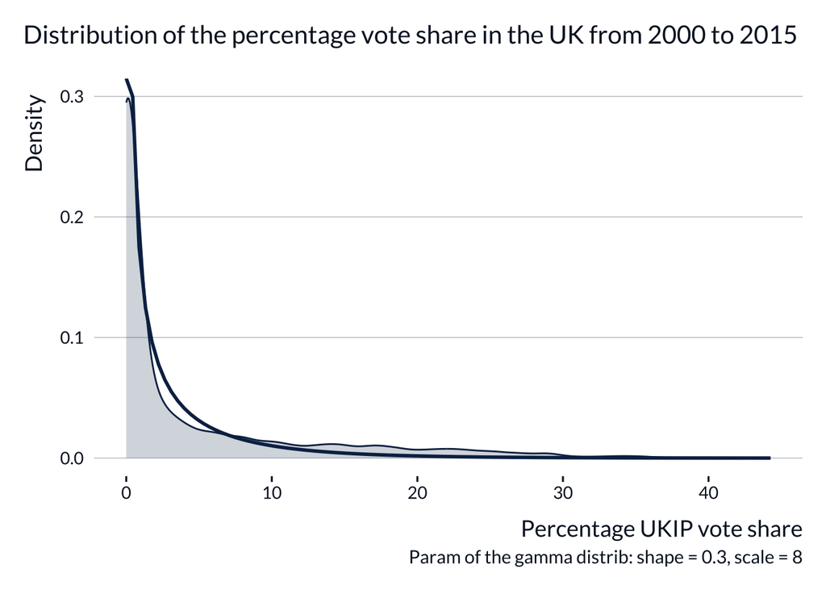

```r
shape_g <- 0.3
scale_g <- 8

fetzer_data |>
  ggplot(aes(x = ukip)) +
  geom_density() +
  geom_function(
    fun = \(x) dgamma(x, shape = shape_g, scale = scale_g),
    linewidth = 1
  ) +
  labs(
    title = "Distribution of the percentage vote share in the UK from 2000 to 2015",
    x = "Percentage UKIP vote share",
    y = "Density",
    caption = str_c(
          "Param of the gamma distrib: shape = ",
          shape_g, ", scale = ", scale_g
          )
  )
```

### UKIP percentage vote decomposition

Let’s assume that voting for UKIP depends on a district component and a region-year component:
$$VoteUkip_{i,r,t} = \alpha + WithinDistrict_{r,t} + BetweenDistricts_{i}$$

Here is the shape of the within-district density distribution:

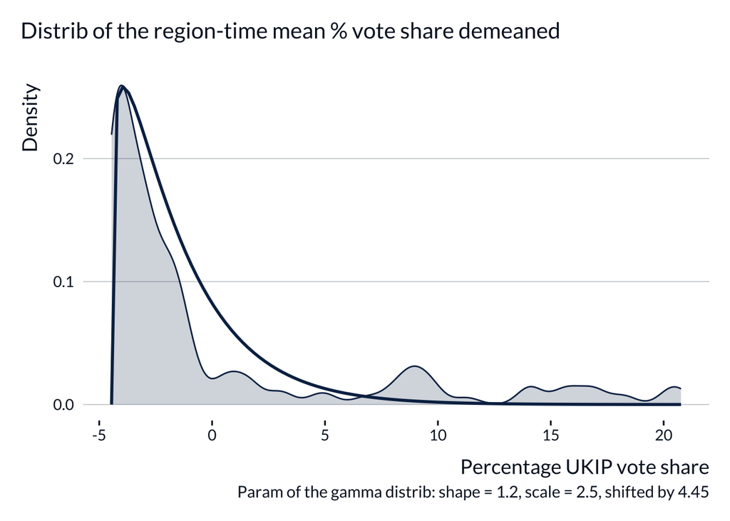

```r
shape_g <- 1.2
scale_g <- 2.5
shift_g <- mean(fetzer_data$ukip, na.rm = TRUE)

fetzer_data |>
  group_by(ryr) |>
  mutate(
    mean = mean(ukip, na.rm = TRUE)
  ) |>
  ungroup() |>
  mutate(
    mean_demeaned = mean - mean(ukip, na.rm = TRUE)
  ) |>
  ggplot(aes(x = mean_demeaned)) +
  geom_density() +
  geom_function(
    fun = \(x) dgamma(x + shift_g, shape = shape_g, scale = scale_g),
    linewidth = 1
  ) +
  labs(
    title = "Distrib of the region-time mean % vote share demeaned",
    x = "Percentage UKIP vote share",
    y = "Density",
    caption = str_c(
          "Param of the gamma distrib: shape = ", shape_g,
          ", scale = ", scale_g,
          ", shifted by ", format(round(shift_g, 2), nsmall = 2)
          )
  )
```

Here is the shape of the between-district density distribution:

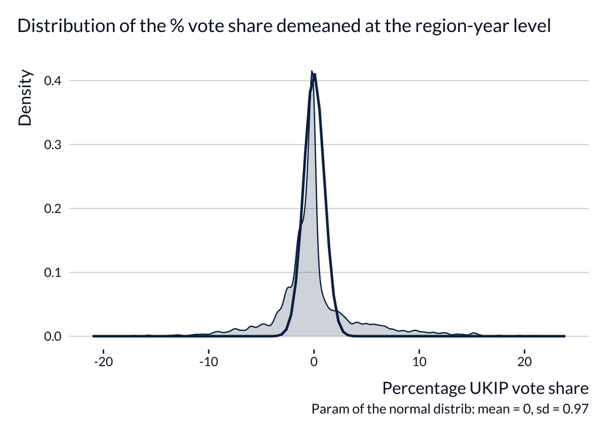

```r
mean_n <- 0
sd_n <- 0.97

fetzer_data |>
  group_by(ryr) |>
  mutate(
    ukip_centered = ukip - mean(ukip, na.rm = TRUE)
  ) |>
  ggplot(aes(x = ukip_centered)) +
  geom_density() +
  geom_function(
    fun = \(x) dnorm(x, mean = mean_n , sd = sd_n),
    linewidth = 1
  ) +
  labs(
    title = "Distribution of the % vote share demeaned at the region-year level",
    x = "Percentage UKIP vote share",
    y = "Density",
    caption = str_c(
          "Param of the normal distrib: mean = ",
          mean_n, ", sd = ", sd_n)
  )
```

## Austerity

Now let’s see how Austerity behaves:

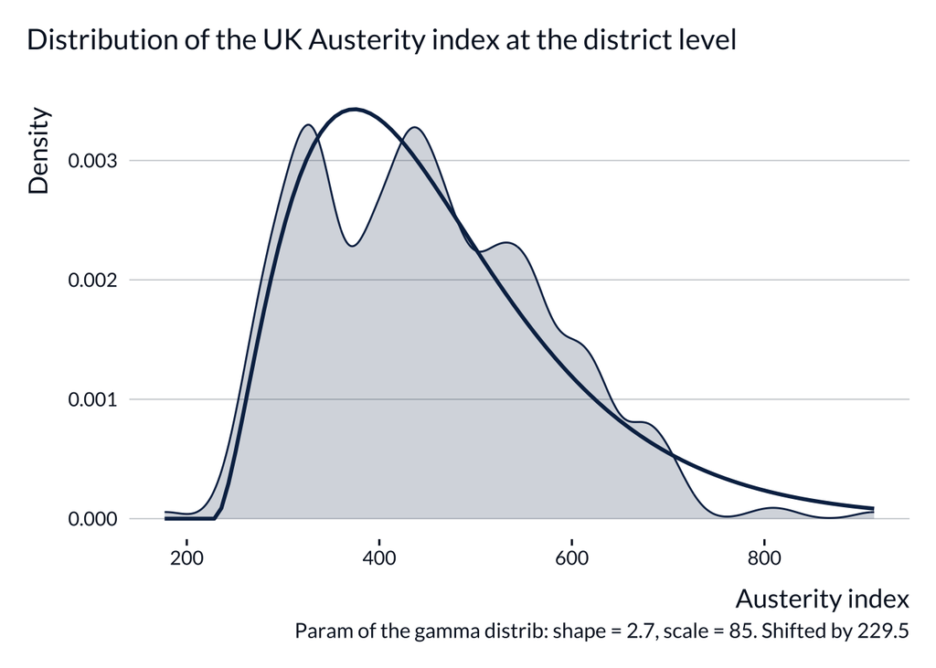

```r
shape_g <- 2.7
scale_g <- 85
shift_g <- shape_g * scale_g


fetzer_data |>
  ggplot(aes(x = austerity)) +
  geom_density() +
  geom_function(
    fun = \(x) dgamma(x - shift_g, shape = shape_g, scale = scale_g),
    linewidth = 1
  ) +
  labs(
    title = "Distribution of the UK Austerity index at the district level",
    x = "Austerity index",
    y = "Density",
    caption = str_c(
          "Param of the gamma distrib: shape = ",
          shape_g, ", scale = ", scale_g,
          ". Shifted by ", shift_g)
  )
```

## Data generating process

After having shaped the different variables needed for the data generating process (DGP), let’s define it with the function `generate_data`. We take the values of the means, standard deviations, shapes and scales of the theoretical distributions of $\lambda_{r,t}$, $Austerity_i$, and $VoteUkip_{d,r,t}$.

Finally, we defined an `epsilon`and a `beta_0` that is changed so that the ```ukip````variable is following the same distribution as that of Fetzer (2019).

```r
generate_data <- function(# number of districts
                          n_d,
                          # number of regions
                          n_r,
                          # mean number of districts per regions
                          mean_per_region,
                          # number of years
                          n_t,
                          # shape of the region-time fixed effect
                          shape_fe_rt,
                          # scale of the region-time fixed effect
                          scale_fe_rt,
                          # shape of austerity
                          shape_austerity,
                          # scale of austerity
                          scale_austerity,
                          # shape of the error term
                          shape_epsilon,
                          # scale of the error term
                          scale_epsilon,
                          # overall mean
                          beta_0,
                          # estimate
                          beta_1,
                          sigma_fe_d) {

  # We build a region tibble of n_r rows
  region <- tibble(r = 1:n_r)
  # We build a year tibble of n_t rows
  year <- tibble(t = 1:n_t)

  # We cross the region and the year tibbles, and add variable that depend on region and time
  crossing_region_year <- crossing(region, year) |>
    mutate(
      # region time fe
      fe_rt = rgamma(n_r * n_t, shape = shape_fe_rt, scale = scale_fe_rt) - beta_0,
      # the index of region - time
      ryr = row_number(),
      # dummy pre-post period
      post = if_else(t > 9, 1, 0)
    )

  # We build a region-district-year tibble
  crossing_region_district_with_year <- region |>
    # Duplicate region by the mean number of districts per region
    uncount(mean_per_region) |>
    # We index each row that represent a single district each
    mutate(d = row_number()) |>
    # We cross this dataset with the year tibble to incorporate the year component
    crossing(year)

  # We build a district-specific tibble
  district <- tibble(d = 1:n_d) |>
    # We add austerity variable as defined with respect to district characteristics
    mutate(
      austerity = rgamma(n_d, shape = shape_austerity, scale = scale_austerity) + shape_austerity * scale_austerity,
      fe_d = rnorm(n_d, 0, sigma_fe_d)
    )

  # We build the final dataset by joining the previous tibbles
  data <- crossing_region_district_with_year |>
    full_join(crossing_region_year) |>
    full_join(district) |>
    # We define variables determined by region, district and year specific characteristics
    mutate(
      # building the epsilon
      total_number_rows =  n(),
      epsilon = rgamma(total_number_rows, shape = shape_epsilon, scale = scale_epsilon),
      # building the interaction term
      effect = post * austerity,
      # ukip vote inferred from previous computations
      ukip = beta_0 + beta_1 * effect + fe_rt + epsilon
    )
}
```

Now, we define our parameters with those determined during the previous sections:

```r
baseline_param <-
  tibble(
    n_d = 385 ,
    n_r = 11,
    n_t = 16,
    mean_per_region = 35,
    shape_fe_rt = 1.2 ,
    scale_fe_rt = 2.5,
    shape_austerity = 2.7,
    scale_austerity = 85,
    beta_0 = -4,
    beta_1 = 0.014,
    shape_epsilon = 0.3,
    scale_epsilon = 1.7,
    sigma_fe_d = 0.97
    )
```

```r
data <- baseline_param |>
  pmap(generate_data) |>
  list_rbind()
```

Now, let’s define the estimation function we named `run_estim()`:

```r
run_estim <- function(data){
  feols(
    fml = ukip ~ effect,
    fixef = c("ryr", "d"), # region-year fe, district fe
    data = data) |>
    summary() |>
    broom::tidy(conf.int = TRUE, conf.level = 0.95)
}
```

```r
data |>
  run_estim() |>
  kable()
```

| term | estimate | std.error | statistic | p.value | conf.low | conf.high |
| --- | --- | --- | --- | --- | --- | --- |
| effect | 0.0139678 | 0.0001644 | 84.98776 | 0 | 0.0136434 | 0.0142921 |

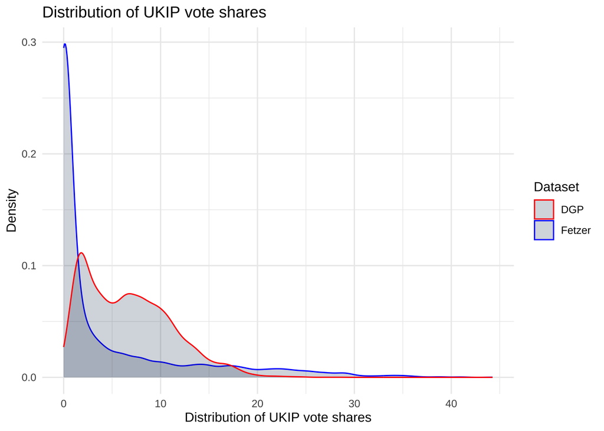

```r
ggplot() +
  geom_density(data = fetzer_data, aes(x = ukip, color = "Fetzer")) +
  geom_density(data = data, aes(x = ukip, color = "DGP")) +
  labs(
    title = "Distribution of UKIP vote shares",
    x = "Distribution of UKIP vote shares",
    y = "Density",
    color = "Dataset"
  ) +
  scale_color_manual(values = c("Fetzer" = "blue", "DGP" = "red" )) +
  theme_minimal()
```

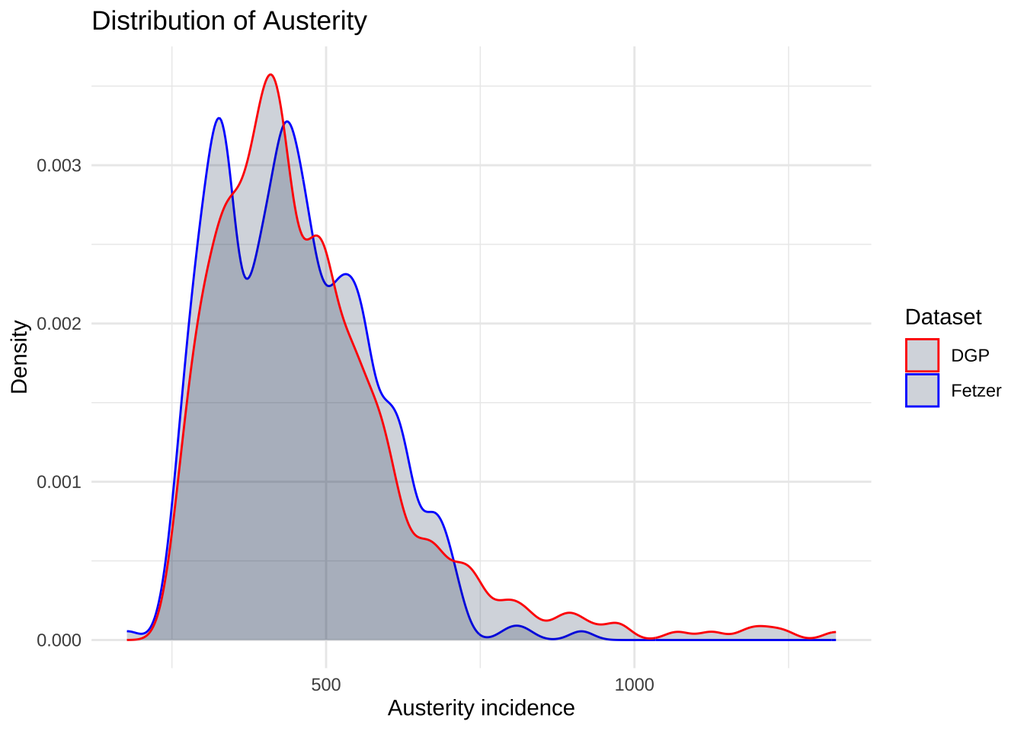

```r
ggplot() +
  geom_density(data = fetzer_data, aes(x = austerity, color = "Fetzer")) +
  geom_density(data = data, aes(x = austerity, color = "DGP")) +
  labs(
    title = "Distribution of Austerity",
    x = "Austerity incidence",
    y = "Density",
    color = "Dataset"
  ) +
  scale_color_manual(values = c("Fetzer" = "blue", "DGP" = "red")) +
  theme_minimal()
```

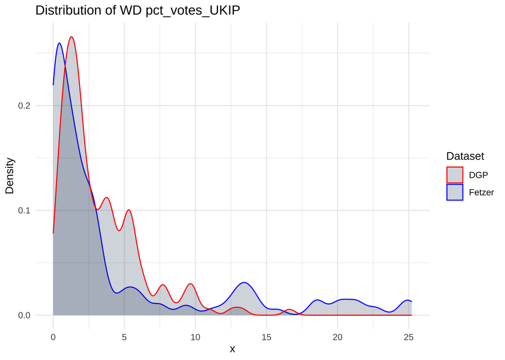

```r
set_2 <- fetzer_data |>
  group_by(ryr) |>
  mutate(
    WD_ukip = mean(ukip, na.rm = TRUE)
  )

ggplot() +
  geom_density(data = set_2, aes(x = WD_ukip, color = "Fetzer")) +
  geom_density(data = data, aes(x = fe_rt - 4  , color = "DGP")) + # - 4 corresponds to the value of overall mean set before in the DGP
  labs(
    title = "Distribution of WD pct_votes_UKIP",
    x = "x",
    y = "Density",
    color = "Dataset"
  ) +
  scale_color_manual(values = c("Fetzer" = "blue", "DGP" = "red")) +
  theme_minimal()
```

To compare the different trends pre and post 2010 on UKIP vote shares, we plotted the distributions from the original dataset and the data we generated:

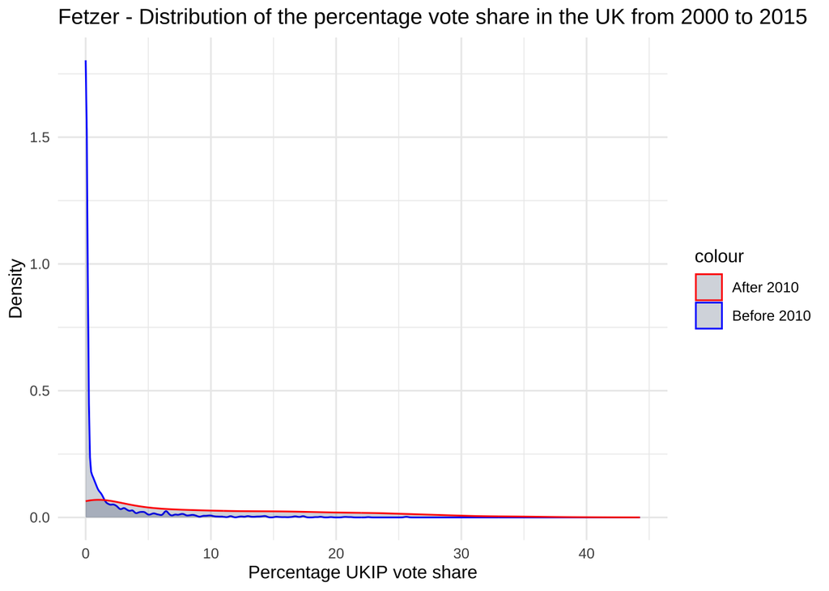

```r
fetzer_data |>
  mutate(before_2010 = if_else(year<2010 & !is.na(year), ukip, NA),
         after_2010 = if_else(year>=2010 & !is.na(year), ukip, NA)) |>
  ggplot() +
  geom_density(aes(x = before_2010, color = "Before 2010")) +
  geom_density(aes(x = after_2010, color = "After 2010")) +
  labs(
    title = "Fetzer - Distribution of the percentage vote share in the UK from 2000 to 2015",
    x = "Percentage UKIP vote share",
    y = "Density"
  ) +
  scale_color_manual(values = c("Before 2010" = "blue", "After 2010" = "red")) +
  theme_minimal()
```

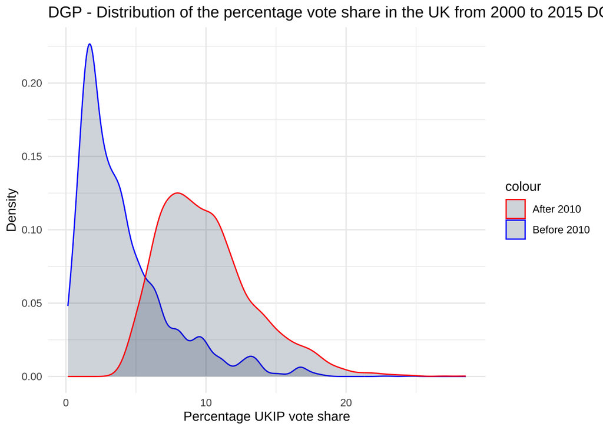

```r
data |>
  mutate(before_2010 = if_else(t<10 & !is.na(t), ukip, NA),
         after_2010 = if_else(t>=10 & !is.na(t), ukip, NA)) |>
  ggplot() +
  geom_density(aes(x = before_2010, color = "Before 2010")) +
  geom_density(aes(x = after_2010, color = "After 2010")) +
  labs(
    title = "DGP - Distribution of the percentage vote share in the UK from 2000 to 2015 DGP",
    x = "Percentage UKIP vote share",
    y = "Density"
  ) +
  scale_color_manual(values = c("Before 2010" = "blue", "After 2010" = "red")) +
  theme_minimal()
```

## Replicate several times

Here is the function we will use to check if the results are similar for more than one experiment.

```r
compute_sim <- function(...){
  generate_data(...) %>%
  run_estim() %>%
    cbind(as_tibble(list(...)))
}
```

We decided to run it for 100 experiments:

```r
n_iter <- 100

param <- baseline_param |>
  uncount(n_iter) # replicates the n_iter rows

result_sim <- param |>
  pmap(compute_sim) |>
  list_rbind() |>
  as_tibble()

result_sim |>
  select(!term) |>
  kable() |>
  scroll_box(height = "200px", width = "100%")
```

| estimate | std.error | statistic | p.value | conf.low | conf.high | n_d | n_r | n_t | mean_per_region | shape_fe_rt | scale_fe_rt | shape_austerity | scale_austerity | beta_0 | beta_1 | shape_epsilon | scale_epsilon | sigma_fe_d |
| --- | --- | --- | --- | --- | --- | --- | --- | --- | --- | --- | --- | --- | --- | --- | --- | --- | --- | --- |
| 0.0139285 | 0.0001660 | 83.92191 | 0 | 0.0136009 | 0.0142560 | 385 | 11 | 16 | 35 | 1.2 | 2.5 | 2.7 | 85 | -4 | 0.014 | 0.3 | 1.7 | 0.97 |
| 0.0141188 | 0.0001799 | 78.46572 | 0 | 0.0137637 | 0.0144739 | 385 | 11 | 16 | 35 | 1.2 | 2.5 | 2.7 | 85 | -4 | 0.014 | 0.3 | 1.7 | 0.97 |
| 0.0140922 | 0.0001636 | 86.15543 | 0 | 0.0137694 | 0.0144151 | 385 | 11 | 16 | 35 | 1.2 | 2.5 | 2.7 | 85 | -4 | 0.014 | 0.3 | 1.7 | 0.97 |
| 0.0140587 | 0.0001612 | 87.22933 | 0 | 0.0137406 | 0.0143768 | 385 | 11 | 16 | 35 | 1.2 | 2.5 | 2.7 | 85 | -4 | 0.014 | 0.3 | 1.7 | 0.97 |
| 0.0138672 | 0.0001704 | 81.40094 | 0 | 0.0135310 | 0.0142034 | 385 | 11 | 16 | 35 | 1.2 | 2.5 | 2.7 | 85 | -4 | 0.014 | 0.3 | 1.7 | 0.97 |
| 0.0138034 | 0.0001410 | 97.88260 | 0 | 0.0135251 | 0.0140817 | 385 | 11 | 16 | 35 | 1.2 | 2.5 | 2.7 | 85 | -4 | 0.014 | 0.3 | 1.7 | 0.97 |
| 0.0139503 | 0.0001700 | 82.06835 | 0 | 0.0136148 | 0.0142858 | 385 | 11 | 16 | 35 | 1.2 | 2.5 | 2.7 | 85 | -4 | 0.014 | 0.3 | 1.7 | 0.97 |
| 0.0141278 | 0.0001656 | 85.29235 | 0 | 0.0138009 | 0.0144547 | 385 | 11 | 16 | 35 | 1.2 | 2.5 | 2.7 | 85 | -4 | 0.014 | 0.3 | 1.7 | 0.97 |
| 0.0139348 | 0.0001612 | 86.47002 | 0 | 0.0136168 | 0.0142529 | 385 | 11 | 16 | 35 | 1.2 | 2.5 | 2.7 | 85 | -4 | 0.014 | 0.3 | 1.7 | 0.97 |
| 0.0139319 | 0.0002219 | 62.77544 | 0 | 0.0134939 | 0.0143699 | 385 | 11 | 16 | 35 | 1.2 | 2.5 | 2.7 | 85 | -4 | 0.014 | 0.3 | 1.7 | 0.97 |
| 0.0138726 | 0.0001891 | 73.34809 | 0 | 0.0134993 | 0.0142459 | 385 | 11 | 16 | 35 | 1.2 | 2.5 | 2.7 | 85 | -4 | 0.014 | 0.3 | 1.7 | 0.97 |
| 0.0142173 | 0.0001881 | 75.60057 | 0 | 0.0138462 | 0.0145885 | 385 | 11 | 16 | 35 | 1.2 | 2.5 | 2.7 | 85 | -4 | 0.014 | 0.3 | 1.7 | 0.97 |
| 0.0140374 | 0.0001833 | 76.56447 | 0 | 0.0136756 | 0.0143992 | 385 | 11 | 16 | 35 | 1.2 | 2.5 | 2.7 | 85 | -4 | 0.014 | 0.3 | 1.7 | 0.97 |
| 0.0141624 | 0.0001637 | 86.49505 | 0 | 0.0138393 | 0.0144856 | 385 | 11 | 16 | 35 | 1.2 | 2.5 | 2.7 | 85 | -4 | 0.014 | 0.3 | 1.7 | 0.97 |
| 0.0140640 | 0.0002116 | 66.47802 | 0 | 0.0136465 | 0.0144815 | 385 | 11 | 16 | 35 | 1.2 | 2.5 | 2.7 | 85 | -4 | 0.014 | 0.3 | 1.7 | 0.97 |
| 0.0138596 | 0.0001626 | 85.25598 | 0 | 0.0135387 | 0.0141804 | 385 | 11 | 16 | 35 | 1.2 | 2.5 | 2.7 | 85 | -4 | 0.014 | 0.3 | 1.7 | 0.97 |
| 0.0141897 | 0.0001650 | 86.01929 | 0 | 0.0138642 | 0.0145153 | 385 | 11 | 16 | 35 | 1.2 | 2.5 | 2.7 | 85 | -4 | 0.014 | 0.3 | 1.7 | 0.97 |
| 0.0140798 | 0.0001519 | 92.66768 | 0 | 0.0137799 | 0.0143796 | 385 | 11 | 16 | 35 | 1.2 | 2.5 | 2.7 | 85 | -4 | 0.014 | 0.3 | 1.7 | 0.97 |
| 0.0141535 | 0.0001731 | 81.75083 | 0 | 0.0138119 | 0.0144952 | 385 | 11 | 16 | 35 | 1.2 | 2.5 | 2.7 | 85 | -4 | 0.014 | 0.3 | 1.7 | 0.97 |
| 0.0138996 | 0.0001560 | 89.11968 | 0 | 0.0135917 | 0.0142074 | 385 | 11 | 16 | 35 | 1.2 | 2.5 | 2.7 | 85 | -4 | 0.014 | 0.3 | 1.7 | 0.97 |
| 0.0140238 | 0.0001710 | 82.03076 | 0 | 0.0136864 | 0.0143612 | 385 | 11 | 16 | 35 | 1.2 | 2.5 | 2.7 | 85 | -4 | 0.014 | 0.3 | 1.7 | 0.97 |
| 0.0140474 | 0.0001836 | 76.52507 | 0 | 0.0136851 | 0.0144097 | 385 | 11 | 16 | 35 | 1.2 | 2.5 | 2.7 | 85 | -4 | 0.014 | 0.3 | 1.7 | 0.97 |
| 0.0140310 | 0.0001692 | 82.90846 | 0 | 0.0136970 | 0.0143650 | 385 | 11 | 16 | 35 | 1.2 | 2.5 | 2.7 | 85 | -4 | 0.014 | 0.3 | 1.7 | 0.97 |
| 0.0142796 | 0.0001756 | 81.31326 | 0 | 0.0139330 | 0.0146262 | 385 | 11 | 16 | 35 | 1.2 | 2.5 | 2.7 | 85 | -4 | 0.014 | 0.3 | 1.7 | 0.97 |
| 0.0139563 | 0.0001664 | 83.87402 | 0 | 0.0136279 | 0.0142847 | 385 | 11 | 16 | 35 | 1.2 | 2.5 | 2.7 | 85 | -4 | 0.014 | 0.3 | 1.7 | 0.97 |
| 0.0137592 | 0.0001753 | 78.51096 | 0 | 0.0134133 | 0.0141050 | 385 | 11 | 16 | 35 | 1.2 | 2.5 | 2.7 | 85 | -4 | 0.014 | 0.3 | 1.7 | 0.97 |
| 0.0140479 | 0.0001938 | 72.50280 | 0 | 0.0136655 | 0.0144303 | 385 | 11 | 16 | 35 | 1.2 | 2.5 | 2.7 | 85 | -4 | 0.014 | 0.3 | 1.7 | 0.97 |
| 0.0138522 | 0.0001698 | 81.59450 | 0 | 0.0135172 | 0.0141873 | 385 | 11 | 16 | 35 | 1.2 | 2.5 | 2.7 | 85 | -4 | 0.014 | 0.3 | 1.7 | 0.97 |
| 0.0139212 | 0.0001689 | 82.43051 | 0 | 0.0135879 | 0.0142546 | 385 | 11 | 16 | 35 | 1.2 | 2.5 | 2.7 | 85 | -4 | 0.014 | 0.3 | 1.7 | 0.97 |
| 0.0137883 | 0.0001417 | 97.27421 | 0 | 0.0135086 | 0.0140681 | 385 | 11 | 16 | 35 | 1.2 | 2.5 | 2.7 | 85 | -4 | 0.014 | 0.3 | 1.7 | 0.97 |

[output cut: 70 more lines]

Here is the density distribution of the estimates, with Fetzer’s estimate in dotted lines:

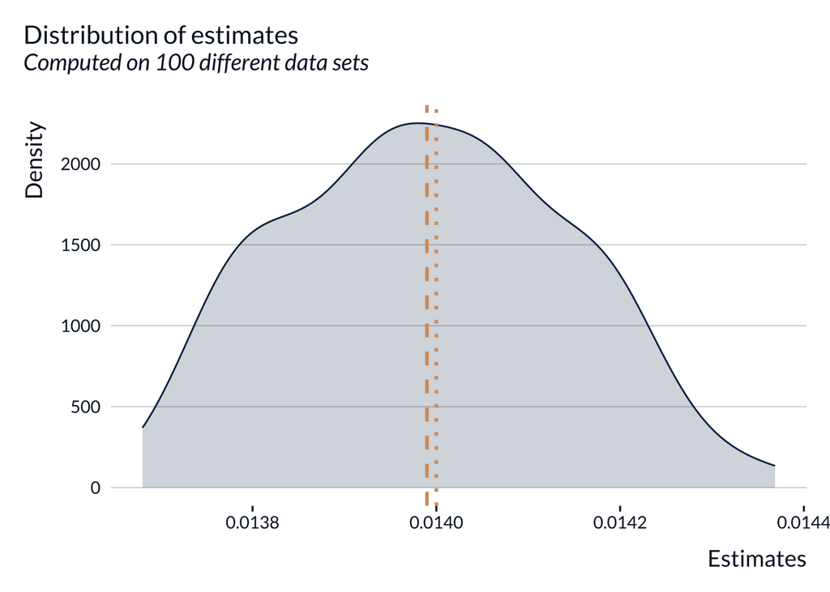

```r
result_sim |>
  ggplot(aes(x = estimate)) +
  geom_density() +
  geom_vline(xintercept = 0.014,
             linewidth = 1,
             linetype = "dotted") +
  geom_vline(
    xintercept = mean(result_sim$estimate),
    linewidth = 1,
    linetype = "dashed"
  ) +
  labs(
    title = paste("Distribution of estimates"),
    subtitle = paste("Computed on", n_iter, "different data sets"),
    x = "Estimates",
    y = "Density"
  )
```

[figure not shown]

```r
result_sim |>
  mutate(sim_id = row_number()) |>
  filter(sim_id < 30) |>
  ggplot(aes(x = sim_id, y = estimate)) +
  geom_pointrange(aes(ymin = conf.low, ymax = conf.high)) +
  geom_point() +
  geom_hline(yintercept = 0.014) +
  labs(
    title = "Estimates",
    subtitle = paste("Computed on 30 different data sets"),
    x = "Simulation id",
    y = "Estimate"
  )
```

# Adding categorical variables

## Replication

We rebuild the UKIP percentage vote in categorical variables:

```r
fetzer_data <- fetzer_data |>
  mutate(ukip_cat = cut(
    ukip,
    breaks = c(0, 5, 10, 15, 100),
    labels = c("0-5", "5-10", "10-15", ">15"),
    include.lowest = TRUE,
    ordered_result = TRUE
  ))
```

Here are the results:

```r
library(MASS)

ordered_logit_FETZER <-
  polr(
    ukip_cat ~ effect,
    data = fetzer_data,
    Hess = TRUE,
    method = "logistic"
  )

# Inspect the result
summary(ordered_logit_FETZER)
```

```
Call:
polr(formula = ukip_cat ~ effect, data = fetzer_data, Hess = TRUE,
    method = "logistic")

Coefficients:
          Value Std. Error t value
effect 0.005794  0.0001992   29.09

Intercepts:
           Value   Std. Error t value
0-5|5-10    2.1182  0.0654    32.3890
5-10|10-15  2.8654  0.0759    37.7385
10-15|>15   3.4838  0.0855    40.7264

Residual Deviance: 4600.307
AIC: 4608.307
(2793 observations deleted due to missingness)
```

```r
ordered_probit_FETZER <-
  polr(
    ukip_cat ~ effect,
    data = fetzer_data,
    Hess = TRUE,
    method = "probit"
  )

# Inspect the result
summary(ordered_probit_FETZER)
```

```
Call:
polr(formula = ukip_cat ~ effect, data = fetzer_data, Hess = TRUE,
    method = "probit")

Coefficients:
          Value Std. Error t value
effect 0.003419  0.0001084   31.52

Intercepts:
           Value   Std. Error t value
0-5|5-10    1.2703  0.0350    36.2638
5-10|10-15  1.6997  0.0399    42.6431
10-15|>15   2.0540  0.0447    45.9982

Residual Deviance: 4567.116
AIC: 4575.116
(2793 observations deleted due to missingness)
```

## Simulation

Let’s do the same thing on our data:

```r
data <- data |>
  mutate(
    ukip_cat = cut(
      ukip,
      breaks = c(0, 5, 10, 15, 100),
      labels = c("0-5", "5-10", "10-15", ">15"),
      include.lowest = TRUE,
      ordered_result = TRUE
    )
  )
```

```r
ordered_logit_sim <- polr(ukip_cat ~ effect, data = data, Hess = TRUE)

# Inspect the result
summary(ordered_logit_sim)
```

```
Call:
polr(formula = ukip_cat ~ effect, data = data, Hess = TRUE)

Coefficients:
          Value Std. Error t value
effect 0.008081  0.0001535   52.65

Intercepts:
           Value   Std. Error t value
0-5|5-10    0.8895  0.0368    24.1721
5-10|10-15  3.8484  0.0706    54.4987
10-15|>15   6.5258  0.1085    60.1383

Residual Deviance: 10202.06
AIC: 10210.06
```

```r
ordered_probit_sim <- polr(ukip_cat ~ effect, data = data, Hess = TRUE, method = "probit")

# Inspect the result
summary(ordered_probit_sim)
```

```
Call:
polr(formula = ukip_cat ~ effect, data = data, Hess = TRUE, method = "probit")

Coefficients:
          Value Std. Error t value
effect 0.004267  7.339e-05   58.15

Intercepts:
           Value   Std. Error t value
0-5|5-10    0.4657  0.0214    21.8119
5-10|10-15  2.0041  0.0321    62.4194
10-15|>15   3.3876  0.0478    70.9265

Residual Deviance: 10490.32
AIC: 10498.32
```